# Hepatitis B Vaccination Rates in the NICU and the Impact of a CDS Tool

BMIN5030 Final Project

Author

Alex Ruan

## 1 Overview

> I am planning to use EHR (Epic, Clarity) data to look at the impact of a clinical decision support tool (Quality Improvement/Safety Rounding Checklist) used by four local neonatal intensive care units on a variety of clinical outcomes, such as vaccination, metabolic screen ordering, and central line days, among other clinical outcomes. Specifically, would hope to show via regression methods that the use of this tool has led to an improvement in these outcomes.

Two faculty mentors include:

> Leah Carr, MD, Assistant Professor of Clinical Pediatrics, Attending Neonatologist and Clinical Informaticist, CHOP/Penn

> Christopher Bonafide, MD, MSCE, Associate Professor of Pediatrics, CHOP/Penn

In discussion with my faculty mentors:

> They suggested that I pare down my initial analysis to focus on one outcome as each one would be a hefty analysis. Specifically, after discussion, they recommended that I focus on hepatitis b vaccination rates as something of clinical interest, but also more manageable in the time frame of this project. Specifically, this project will aim to assess the impact of a QI/Safety Rounding Checklist - a clinical decision support tool - implemented across four NICUs on hepatitis b vaccination rates. This project will use deidentified EHR data (Epic, Clarity) and analysis will be done in aggregate to not reveal local site data.

> Link to github: https://github.com/alexbruan/BMIN5030_Final_Project_Fork

## 2 Introduction

Describe the problem addressed, its significance, and some background to motivate the problem. This should extend what is in the Section 1.

Explain why your problem is interdisciplinary, what fields can contribute to its understanding, and incorporate background related to what you learned from meeting with faculty/staff.

> There is a well-established body of research associating checklists with improved outcomes, from adherence to best practice guidelines, to decreased risk of infection, to improved preferred language documentation. (ref 1-4) While prior work in the Children’s Hospital of Philadelphia NICU has demonstrated success with Epic integration of a checklist, this was limited to a single quaternary academic unit. (ref 5)

> In 2019, another local NICU, a level III NICU, implemented a REDCap-based checklist to support local quality improvement (QI) and safety initiatives, but compliance with the tool was less than 50%. A 2023 provider survey revealed low perceived relevance and high burden, with key barriers including workflow interruptions and tool accessibility. Feedback strongly supported Epic integration. The same instance of Epic is live in four NICUs in the same health system. Discussions with leadership of these NICUs revealed strong support for the design and implementation of a standardized network-wide tool, allowing for the development of an Epic-based CDS tool.

> In the period of December 2024-March 2025, the four NICUs went live with this tool. Key results from this project include a statistically significant increase in the average biweekly compliance from 25% to 90% from October 2023 to October 2025 based on a statistical process control p-chart at a pilot NICU. Across all four NICUs, average compliance was 86% as of October 2025. Survey data (67% response rate, 66/98) indicated that most NICU clinicians found the tool easy to use, clinically relevant, and beneficial for patient safety.

> While there has been data to show that such a tool supports clinical processes and workflows, it is unclear what effect it may have on clinical outcomes of interest. As such, this project will aim to assess the impact of a QI/Safety Rounding Checklist - a clinical decision support tool - implemented across four NICUs on hepatitis b vaccination rates. This project will use deidentified EHR data (Epic, Clarity) and analysis will be done in aggregate to not reveal local site data.

## 3 Methods

Describe the data used and general methodological approach used to address the problem described in the Section 2. Subsequently, incorporate full R code necessary to retrieve and clean data, and perform analysis. Be sure to include a description of code so that others (including your future self) can understand what you are doing and why.

> This project utilizes deidentified EHR data from Epic’s Clarity, which is a relational database with a normalized data model. This data is transferred from Chronicles, which is a hierarchical database with real-time data. This data flows from Chronicles to Clarity based on institutional ETL processes.

> All NICU patients from March 2019 through September 2025 will be included in this analysis. March 2019 was chosen as one of the NICUs previously had a REDCap based checklist that went live in March 2019. Moreover, recommendations for Hepatitis B vaccination timing depends on birth weight. The first dose should ideally be given within 24 hours of birth (though this may differ in the critical care setting) if birth weight >/= 2000 grams or first dose by 1 month of life or at time of discharge from the hospital if birth weight <2000 grams. For the purposes of this analysis, only the >/= 2000 gram cohort will be included. Given the CDS tool asks about vaccination once a week, and is not restricted based on any further logic built into the EHR, this analysis looks at if the patient received vaccination at two time points 1) within the first 7 days and 2) by the time of discharge. Basic demographic information will be included, such as birth weight, gestational age, race, ethnicity, and sex. Birth month and year is included to help determine if the patient was born pre/post CDS implementation. Clinical co-variates of interest, which are markers of clinical severity, are also included such as, vitamin k administration, pressors within 7 days, antibiotics within 7 days, diagnosis of hypoxic ischemic encephalopathy, intubated within 7 days, history of non-invasive respiratory support within 7 days, history of central line within 7 days. Patients who died were excluded. Patients who had mothers with a history of hepatitis b infection were excluded since they are treated different clinically from newborns without maternal history of infection (given hepatitis b vaccine and hepatitis b immunoglobulin within 12 hours of life). CDS tool use within 7 days as well as if it was used at all was also included. All of these columns were joined from various tables in Clarity so just one CSV is required to be loaded into R.

### 3.1 R Library

```r
#first I'll load the relevant packages
library(tidyverse)
library(lubridate)
library(janitor)
library(rstatix)
library(broom)
library(gtsummary)
library(stringr)
library(zoo)
library(scales)
```

### 3.2 Load CSV and Clean Data

```r
#read in my csv
hepb <-read_csv("BMIN5030_Dataset.csv" )
#clean data, excluding died during encounter, maternal hep b status, cleaning race, ethnicity, dates, sorting chronologically
#cleaning of site data is in a separate hidden chunk to keep sites truly deidentified
hepb_clean <- hepb %>%
  filter(died_during_encounter == 0, maternal_hepb_status == 0) %>%
  mutate(
    sex = factor(sex, levels = c("Female", "Male")),
    birth_weight_category = as.factor(birth_weight_category),
    ga = as.numeric(na_if(ga_complete_weeks, "null")),
    race = case_when(
      str_detect(patient_race_all_lines, regex("Declined", ignore_case = TRUE)) |
        str_detect(patient_race_all_lines, regex("Unknown", ignore_case = TRUE)) |
        is.na(patient_race_all_lines) ~ "Declined/Unknown",
      str_detect(patient_race_all_lines, regex("Black or African American", ignore_case = TRUE)) ~
        "Black or African American",
      str_detect(patient_race_all_lines, regex("Asian", ignore_case = TRUE)) ~ "Asian",
      str_detect(patient_race_all_lines, regex("White", ignore_case = TRUE)) ~ "White",
      TRUE ~ "Other"
    ),
    race = factor(
      race,
      levels = c("White", "Black or African American", "Asian", "Other", "Declined/Unknown")
    ),
    ethnicity = case_when(
      patient_ethnic_group == "Hispanic Latino"        ~ "Hispanic Latino",
      patient_ethnic_group == "Not Hispanic or Latino" ~ "Not Hispanic or Latino",
      TRUE                                             ~ "Declined/Missing"
    ),
    ethnicity = factor(
      ethnicity,
      levels = c("Hispanic Latino", "Not Hispanic or Latino", "Declined/Missing")
    ),
    birth_month_year      = na_if(birth_month_year, "null"),
    birth_month_year_str  = sub("^(\\d{2})-(\\w{3})$", "01-\\2-20\\1", birth_month_year),
    month_year            = dmy(birth_month_year_str)
  ) %>%
  arrange(month_year) %>%  # sort chronologically
  select(
    -patient_ethnic_group,
    -patient_race_all_lines,
    -birth_month_year_str
  ) %>%
  filter_at(vars(ga, sex, birth_weight_grams), all_vars(!is.na(.)))
```

## 4 Results

Describe your results and include relevant tables, plots, and code/comments used to obtain them. You may refer to the Section 3 as needed. End with a brief conclusion of your findings related to the question you set out to address. You can include references if you’d like, but this is not required.

### 4.1 Creating Table 1

```r
#First, create a Table 1 to distinguish pre/post cohorts. Of note, based on the SQL query, the patients are all >/= 2000 grams for birth weight, exclude patients that died, and exclude patients with mothers who had hepatitis b.
table1 <- hepb_clean %>%
  mutate(
    post_cds_group = factor(
      post_cds_flag,
      levels = c(0, 1),
      labels = c("Pre-CDS", "Post-CDS"))) %>%
  select(post_cds_group,sex,race,ethnicity,loc_name,ga,birth_weight_grams, birth_weight_category,has_hie,intubated_within_7_days,noninvasive_within_7_days, central_line_within_7_days,pressor_within_7_days,abx_within_7_days) %>%
  tbl_summary(
    by = post_cds_group,
    type = list(
      ga ~ "continuous",
      birth_weight_grams ~ "continuous"
    ),
    statistic = list(
      all_continuous()  ~ "{mean} ({sd})",
      all_categorical() ~ "{n} ({p}%)"
    ),
    missing = "ifany") %>%
  add_overall() %>% modify_header(label ~ "**Characteristic**") %>% bold_labels()

table1
```

| **Characteristic** | **Overall** N = 8,529<sup>1</sup> | **Pre-CDS** N = 7,702<sup>1</sup> | **Post-CDS** N = 827<sup>1</sup> |
| --- | --- | --- | --- |
| sex |  |  |  |
| Female | 3,499 (41%) | 3,142 (41%) | 357 (43%) |
| Male | 5,030 (59%) | 4,560 (59%) | 470 (57%) |
| race |  |  |  |
| White | 4,088 (48%) | 3,663 (48%) | 425 (51%) |
| Black or African American | 2,670 (31%) | 2,431 (32%) | 239 (29%) |
| Asian | 646 (7.6%) | 582 (7.6%) | 64 (7.7%) |
| Other | 934 (11%) | 869 (11%) | 65 (7.9%) |
| Declined/Unknown | 191 (2.2%) | 157 (2.0%) | 34 (4.1%) |
| ethnicity |  |  |  |
| Hispanic Latino | 975 (11%) | 869 (11%) | 106 (13%) |
| Not Hispanic or Latino | 7,425 (87%) | 6,721 (87%) | 704 (85%) |
| Declined/Missing | 129 (1.5%) | 112 (1.5%) | 17 (2.1%) |
| loc_name |  |  |  |
| Site 1 | 2,044 (24%) | 1,833 (24%) | 211 (26%) |
| Site 2 | 1,496 (18%) | 1,305 (17%) | 191 (23%) |
| Site 3 | 1,062 (12%) | 987 (13%) | 75 (9.1%) |
| Site 4 | 3,927 (46%) | 3,577 (46%) | 350 (42%) |
| ga | 37.15 (2.26) | 37.14 (2.26) | 37.24 (2.25) |
| birth_weight_grams | 3,033 (646) | 3,030 (644) | 3,067 (668) |
| birth_weight_category |  |  |  |
| c. LBW (1501 - 2500g) | 2,194 (26%) | 1,985 (26%) | 209 (25%) |
| d. NBW (2501 - 4000g) | 5,687 (67%) | 5,137 (67%) | 550 (67%) |
| e. HBW (4001g or more) | 648 (7.6%) | 580 (7.5%) | 68 (8.2%) |
| has_hie | 165 (1.9%) | 142 (1.8%) | 23 (2.8%) |
| intubated_within_7_days | 443 (5.2%) | 386 (5.0%) | 57 (6.9%) |
| noninvasive_within_7_days | 2,762 (32%) | 2,450 (32%) | 312 (38%) |
| central_line_within_7_days | 845 (9.9%) | 758 (9.8%) | 87 (11%) |
| pressor_within_7_days | 51 (0.6%) | 47 (0.6%) | 4 (0.5%) |
| abx_within_7_days | 4,206 (49%) | 3,757 (49%) | 449 (54%) |

<sup>1</sup> n (%); Mean (SD)

### 4.2 Data Visualization, Tool Use

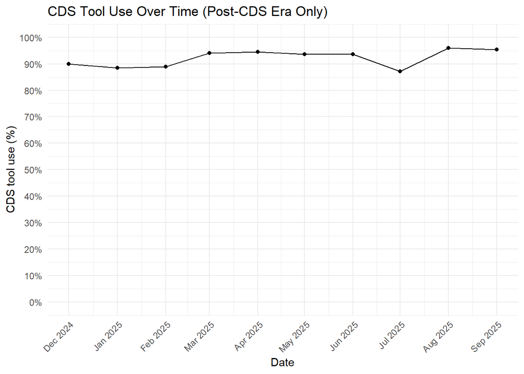

```r
# Monthly CDS tool use
tool_monthly <- hepb_clean %>%
  filter(post_cds_flag == 1) %>%
  group_by(month_year) %>%
  summarise(
    n_births       = n(),
    tool_use_rate  = mean(cds_tool_used_at_all, na.rm = TRUE),
    .groups        = "drop"
  ) %>% arrange(month_year)

ggplot(tool_monthly, aes(x = month_year, y = tool_use_rate)) +
  geom_line() +
  geom_point() +
  scale_x_date(
    date_labels = "%b %Y",
    date_breaks = "1 month"
  ) +
  scale_y_continuous(
    labels = percent_format(accuracy = 1),
    limits = c(0, 1),
    breaks = seq(0, 1, by = 0.1)
  ) +
  labs(x = "Date", y = "CDS tool use (%)", title = "CDS Tool Use Over Time (Post-CDS Era Only)") +
  theme_minimal() +
  theme(axis.text.x = element_text(angle = 45, hjust = 1))
```

### 4.3 Data Visualization, Plotting Hepatitis B Vaccination Rate Over Time (March 2019 - September 2025)

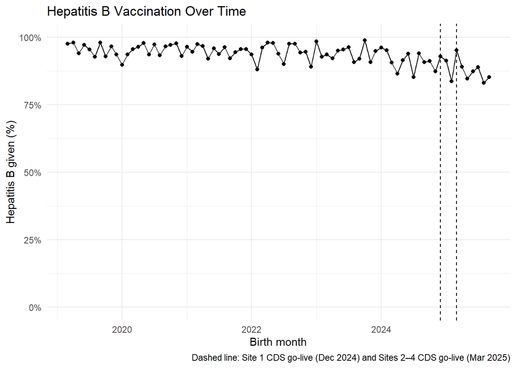

```r
hepb_monthly <- hepb_clean %>%
  group_by(month_year) %>%
  summarise(
    n_births   = n(),
    hep_b_rate = mean(hep_b_given, na.rm = TRUE),
    .groups    = "drop"
  ) %>%
  arrange(month_year)

ggplot(hepb_monthly, aes(x = month_year, y = hep_b_rate)) +
  geom_line() +
  geom_point() +
  geom_vline(xintercept = as.Date("2024-12-01"),
             linetype = "dashed") +
  geom_vline(xintercept = as.Date("2025-03-01"),
             linetype = "dashed") +
  scale_y_continuous(labels = percent_format(accuracy = 1),
                     limits = c(0, 1)) +
  labs(
    x = "Birth month",
    y = "Hepatitis B given (%)",
    title = "Hepatitis B Vaccination Over Time",
    caption = "Dashed line: Site 1 CDS go-live (Dec 2024) and Sites 2–4 CDS go-live (Mar 2025)"
  ) + theme_minimal()
```

### 4.4 Bar Plots, Pre/Post

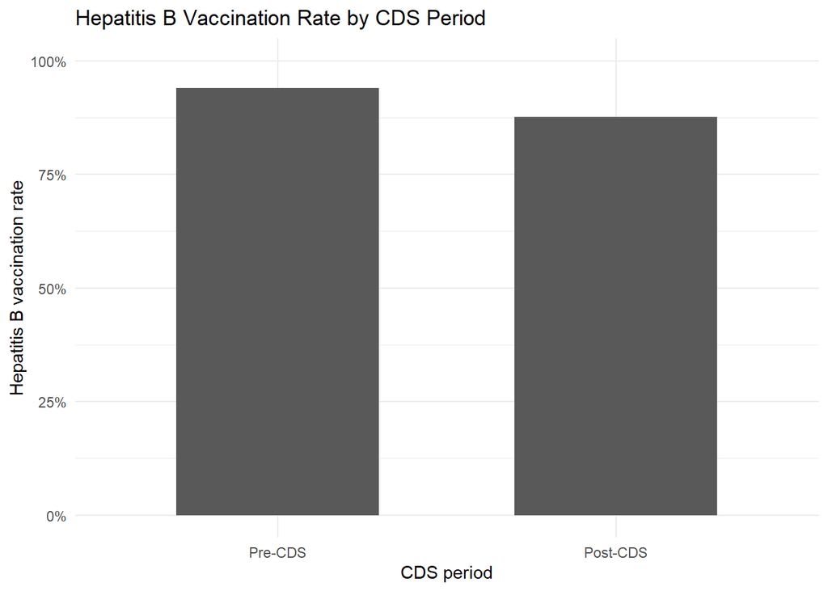

```r
# Bar plot for Hep B given at all
ggplot(hepb_clean %>%
    mutate(CDS_period = factor(post_cds_flag,levels = c(0, 1),labels = c("Pre-CDS", "Post-CDS"))) %>%
    group_by(CDS_period) %>%
    summarise(prop = mean(hep_b_given, na.rm = TRUE), .groups = "drop"),
  aes(x = CDS_period, y = prop)
) + geom_col(width = 0.6) +
  scale_y_continuous(labels = percent_format(accuracy = 1),
                     limits = c(0, 1)) + labs(
    x = "CDS period",
    y = "Hepatitis B vaccination rate",
    title = "Hepatitis B Vaccination Rate by CDS Period"
  ) +
  theme_minimal()
```

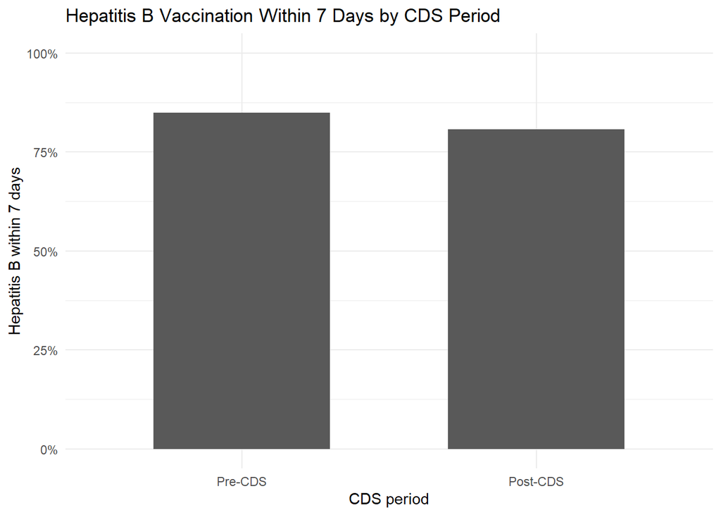

```r
# Bar plot for Hep B within 7 days
ggplot(hepb_clean %>%
    mutate(CDS_period = factor(post_cds_flag,levels = c(0, 1),labels = c("Pre-CDS", "Post-CDS"))) %>%
    group_by(CDS_period) %>%
    summarise(prop = mean(hep_b_within_7_days, na.rm = TRUE),
              .groups = "drop"),
  aes(x = CDS_period, y = prop)
) +
  geom_col(width = 0.6) +
  scale_y_continuous(labels = percent_format(accuracy = 1),
                     limits = c(0, 1)) + labs(
    x = "CDS period",
    y = "Hepatitis B within 7 days",
    title = "Hepatitis B Vaccination Within 7 Days by CDS Period"
  ) +
  theme_minimal()
```

### 4.5 Chi Square Tests

```r
#Setting up chi square hep b given at all pre/post
hepb_chi <- hepb_clean %>%
  mutate(
    post_cds_group = factor(
      post_cds_flag,
      levels = c(0, 1),
      labels = c("Pre-CDS", "Post-CDS")
    )
  )

#2x2 table: Hep B given (0/1) by pre/post
tab_hepb <- table(
  HepB_given    = hepb_chi$hep_b_given,
  CDS_period    = hepb_chi$post_cds_group
)

tab_hepb
```

```
          CDS_period
HepB_given Pre-CDS Post-CDS
         0     460      102
         1    7242      725
```

```r
prop.table(tab_hepb, margin = 2)
```

```
          CDS_period
HepB_given    Pre-CDS   Post-CDS
         0 0.05972475 0.12333736
         1 0.94027525 0.87666264
```

```r
# Chi-square
chisq.test(tab_hepb)
```

```
    Pearson's Chi-squared test with Yates' continuity correction

data:  tab_hepb
X-squared = 48.07, df = 1, p-value = 4.113e-12
```

```r
#Chi square looking at for those patients in the post cds period if there was a difference

# Restrict to post-CDS infants
post_cds <- hepb_clean %>%
  filter(post_cds_flag == 1)

# 2x2 table: Hep B given vs CDS tool used
table_tool_use <- table(
  HepB_given       = post_cds$hep_b_given,
  CDS_tool_used    = post_cds$cds_tool_used_at_all
)

table_tool_use
```

```
          CDS_tool_used
HepB_given   0   1
         0   8  94
         1  49 676
```

```r
prop.table(table_tool_use, margin = 2)
```

```
          CDS_tool_used
HepB_given         0         1
         0 0.1403509 0.1220779
         1 0.8596491 0.8779221
```

```r
chisq.test(table_tool_use)
```

```
    Pearson's Chi-squared test with Yates' continuity correction

data:  table_tool_use
X-squared = 0.038458, df = 1, p-value = 0.8445
```

```r
#Sensitivity analysis, look at hep b vaccine given at all vs. pre/post while excluding severely ill patients, and then look at hep b given at all only in the post cds era while excluding severely ill patients
clinical_flags <- c(
  "has_hie",
  "intubated_within_7_days",
  "noninvasive_within_7_days",
  "central_line_within_7_days",
  "pressor_within_7_days",
  "abx_within_7_days"
)

#chi square, hep b given at all, pre/post, exclude severely ill patients
hepb_low_risk <- hepb_clean %>% filter(across(all_of(clinical_flags), ~ . == 0))
hepb_low_risk <- hepb_low_risk %>%
  mutate(
    post_cds_group = factor(
      post_cds_flag,
      levels = c(0, 1),
      labels = c("Pre-CDS", "Post-CDS")
    )
  )

table_low_risk <- table(
  HepB_given   = hepb_low_risk$hep_b_given,
  CDS_period   = hepb_low_risk$post_cds_group
)

table_low_risk
```

```
          CDS_period
HepB_given Pre-CDS Post-CDS
         0     184       37
         1    2771      219
```

```r
prop.table(table_low_risk, margin = 2)
```

```
          CDS_period
HepB_given    Pre-CDS   Post-CDS
         0 0.06226734 0.14453125
         1 0.93773266 0.85546875
```

```r
chisq.test(table_low_risk)
```

```
    Pearson's Chi-squared test with Yates' continuity correction

data:  table_low_risk
X-squared = 23.61, df = 1, p-value = 1.18e-06
```

```r
#chi square, post cds era only, exclude sick patients
post_cds_low <- hepb_low_risk %>% filter(post_cds_flag == 1)

table_tool_low <- table(
  HepB_given    = post_cds_low$hep_b_given,
  CDS_tool_used = post_cds_low$cds_tool_used_at_all
)

table_tool_low
```

```
          CDS_tool_used
HepB_given   0   1
         0   3  34
         1  26 193
```

```r
prop.table(table_tool_low, margin = 2)
```

```
          CDS_tool_used
HepB_given         0         1
         0 0.1034483 0.1497797
         1 0.8965517 0.8502203
```

```r
#used fisher given n=3 in one case
fisher.test(table_tool_low)
```

```
    Fisher's Exact Test for Count Data

data:  table_tool_low
p-value = 0.7785
alternative hypothesis: true odds ratio is not equal to 1
95 percent confidence interval:
 0.1204577 2.3273726
sample estimates:
odds ratio
 0.6559486
```

```r
#chisquare hep b within 7 days all patients, pre/post

hepb_7 <- hepb_clean %>%
  mutate(
    CDS_period = factor(
      post_cds_flag,
      levels = c(0, 1),
      labels = c("Pre-CDS", "Post-CDS")
    )
  ) %>%
  filter(!is.na(hep_b_within_7_days))

table_hepb_7 <- table(
  HepB_within_7_days = hepb_7$hep_b_within_7_days,
  CDS_period         = hepb_7$CDS_period
)

table_hepb_7
```

```
                  CDS_period
HepB_within_7_days Pre-CDS Post-CDS
                 0    1158      160
                 1    6544      667
```

```r
prop.table(table_hepb_7, margin = 2)
```

```
                  CDS_period
HepB_within_7_days   Pre-CDS  Post-CDS
                 0 0.1503506 0.1934704
                 1 0.8496494 0.8065296
```

```r
chisq.test(table_hepb_7)
```

```
    Pearson's Chi-squared test with Yates' continuity correction

data:  table_hepb_7
X-squared = 10.3, df = 1, p-value = 0.00133
```

```r
#now look in the post cds era, hep b within 7 days

hepb_7_tool <- hepb_clean %>%
  filter(
    post_cds_flag == 1,
    !is.na(hep_b_within_7_days),
    !is.na(cds_tool_used_at_all)
  ) %>%
  mutate(
    CDS_tool_used = factor(
      cds_tool_used_at_all,
      levels = c(0, 1),
      labels = c("No tool use", "Tool used at all")))

table_hepb_7_tool <- table(
  HepB_within_7_days = hepb_7_tool$hep_b_within_7_days,
  CDS_tool_used      = hepb_7_tool$CDS_tool_used)

table_hepb_7_tool
```

```
                  CDS_tool_used
HepB_within_7_days No tool use Tool used at all
                 0           8              152
                 1          49              618
```

```r
prop.table(table_hepb_7_tool, margin = 2)
```

```
                  CDS_tool_used
HepB_within_7_days No tool use Tool used at all
                 0   0.1403509        0.1974026
                 1   0.8596491        0.8025974
```

```r
chisq.test(table_hepb_7_tool)
```

```
    Pearson's Chi-squared test with Yates' continuity correction

data:  table_hepb_7_tool
X-squared = 0.7716, df = 1, p-value = 0.3797
```

```r
# Sensitivity analysis - account for clinical severity for hep b within 7 days and then do the chi square
hepb_7_low_risk <- hepb_clean %>%
  filter(
    has_hie == 0,
    intubated_within_7_days == 0,
    noninvasive_within_7_days == 0,
    central_line_within_7_days == 0,
    pressor_within_7_days == 0,
    abx_within_7_days == 0,
    !is.na(hep_b_within_7_days)
  ) %>%
  mutate(
    CDS_period = factor(
      post_cds_flag,
      levels = c(0, 1),
      labels = c("Pre-CDS", "Post-CDS")
    )
  )

table_7_low_clin_risk <- table(
  HepB_within_7_days = hepb_7_low_risk$hep_b_within_7_days,
  CDS_period         = hepb_7_low_risk$CDS_period
)

table_7_low_clin_risk
```

```
                  CDS_period
HepB_within_7_days Pre-CDS Post-CDS
                 0     270       42
                 1    2685      214
```

```r
prop.table(table_7_low_clin_risk, margin = 2)
```

```
                  CDS_period
HepB_within_7_days    Pre-CDS   Post-CDS
                 0 0.09137056 0.16406250
                 1 0.90862944 0.83593750
```

```r
chisq.test(table_7_low_clin_risk)
```

```
    Pearson's Chi-squared test with Yates' continuity correction

data:  table_7_low_clin_risk
X-squared = 13.374, df = 1, p-value = 0.0002551
```

### 4.6 Logistic Regression

```r
#Create a high acuity column for logistic regression
hepb_model <- hepb_clean %>%
  mutate(
    high_acuity = if_else(
      has_hie == 1 |
        intubated_within_7_days == 1 |
        noninvasive_within_7_days == 1 |
        central_line_within_7_days == 1 |
        pressor_within_7_days == 1 |
        abx_within_7_days == 1,
      1L, 0L
    ),
    high_acuity = factor(high_acuity, levels = c(0, 1), labels = c("No", "Yes")),)

#logistic regression, outcome: hep b given, predictor: pre/post cds era
glm_hepb_ever_prepost <- glm(
  hep_b_given ~ post_cds_flag + loc_name + ga + sex + race + ethnicity +
    high_acuity,
  data   = hepb_model,
  family = binomial
)

tidy_hepb_ever_prepost <- tidy(
  glm_hepb_ever_prepost,
  exponentiate = TRUE,
  conf.int     = TRUE
)

tidy_hepb_ever_prepost
```

```
# A tibble: 14 × 7
   term                 estimate std.error statistic  p.value conf.low conf.high
   <chr>                   <dbl>     <dbl>     <dbl>    <dbl>    <dbl>     <dbl>
 1 (Intercept)          1080.       0.796     8.78   1.68e-18  230.     5201.
 2 post_cds_flag           0.441    0.118    -6.93   4.29e-12    0.351     0.558
 3 loc_nameSite 2          0.646    0.147    -2.97   2.97e- 3    0.484     0.862
 4 loc_nameSite 3          0.465    0.155    -4.95   7.29e- 7    0.344     0.630
 5 loc_nameSite 4          1.03     0.121     0.261  7.94e- 1    0.813     1.30
 6 ga                      0.908    0.0203   -4.74   2.10e- 6    0.872     0.945
 7 sexMale                 0.954    0.0899   -0.522  6.01e- 1    0.799     1.14
 8 raceBlack or Africa…    0.637    0.107    -4.21   2.53e- 5    0.517     0.786
 9 raceAsian               2.66     0.246     3.98   6.96e- 5    1.69      4.44
10 raceOther               1.01     0.198     0.0577 9.54e- 1    0.692     1.50
11 raceDeclined/Unknown    0.536    0.266    -2.34   1.92e- 2    0.325     0.928
12 ethnicityNot Hispan…    0.649    0.197    -2.19   2.86e- 2    0.437     0.948
13 ethnicityDeclined/M…    0.491    0.350    -2.03   4.23e- 2    0.255     1.02
14 high_acuityYes          1.18     0.0923    1.79   7.34e- 2    0.984     1.41
```

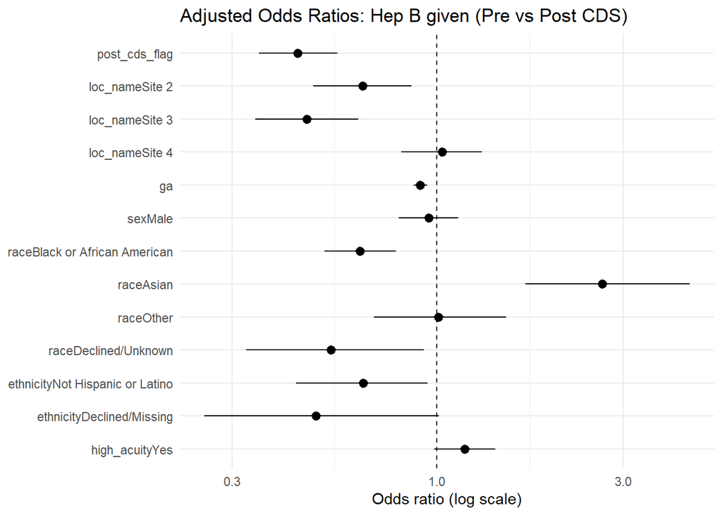

```r
#Forest Plot

forest_hepb_prepost <- tidy_hepb_ever_prepost %>%
  filter(term != "(Intercept)") %>%
  mutate(term = factor(term, levels = rev(term)))

ggplot(forest_hepb_prepost,
       aes(x = term, y = estimate, ymin = conf.low, ymax = conf.high)) +
  geom_pointrange() +
  geom_hline(yintercept = 1, linetype = "dashed") +
  coord_flip() +
  scale_y_log10() +
  labs(x = NULL,
       y = "Odds ratio (log scale)",
       title = "Adjusted Odds Ratios: Hep B given (Pre vs Post CDS)") +
  theme_minimal()
```

```r
#logistic regression, outcome hep b given, predictor tool use (post cds era only)
hepb_model_post <- hepb_model %>%
  filter(
    post_cds_flag == 1,
    !is.na(cds_tool_used_at_all)
  ) %>%
  mutate(
    cds_tool_used = factor(
      cds_tool_used_at_all,
      levels = c(0, 1),
      labels = c("No tool use", "Tool used at all")
    )
  )

model_hepb_any_tool_use <- glm(
  hep_b_given ~ cds_tool_used + loc_name + ga + sex + race + ethnicity +
    high_acuity,
  data   = hepb_model_post,
  family = binomial
)

tidy_hepb_any_tool_use <- tidy(
  model_hepb_any_tool_use,
  exponentiate = TRUE,
  conf.int     = TRUE
)

tidy_hepb_any_tool_use
```

```
# A tibble: 14 × 7
   term                  estimate std.error statistic p.value conf.low conf.high
   <chr>                    <dbl>     <dbl>     <dbl>   <dbl>    <dbl>     <dbl>
 1 (Intercept)            225.       2.04       2.65  0.00796   4.36   13180.
 2 cds_tool_usedTool us…    1.22     0.413      0.478 0.633     0.507      2.61
 3 loc_nameSite 2           0.373    0.346     -2.85  0.00436   0.186      0.727
 4 loc_nameSite 3           0.391    0.437     -2.15  0.0318    0.168      0.942
 5 loc_nameSite 4           0.768    0.308     -0.857 0.392     0.413      1.39
 6 ga                       0.930    0.0508    -1.42  0.156     0.841      1.03
 7 sexMale                  0.803    0.221     -0.991 0.322     0.518      1.23
 8 raceBlack or African…    0.657    0.263     -1.60  0.110     0.392      1.10
 9 raceAsian                5.05     0.742      2.18  0.0290    1.48      31.7
10 raceOther                1.63     0.626      0.782 0.434     0.516      6.32
11 raceDeclined/Unknown     1.92     0.779      0.835 0.404     0.511     12.6
12 ethnicityNot Hispani…    0.567    0.481     -1.18  0.239     0.203      1.36
13 ethnicityDeclined/Mi…    0.408    0.879     -1.02  0.308     0.0822     3.04
14 high_acuityYes           1.31     0.230      1.17  0.243     0.828      2.04
```

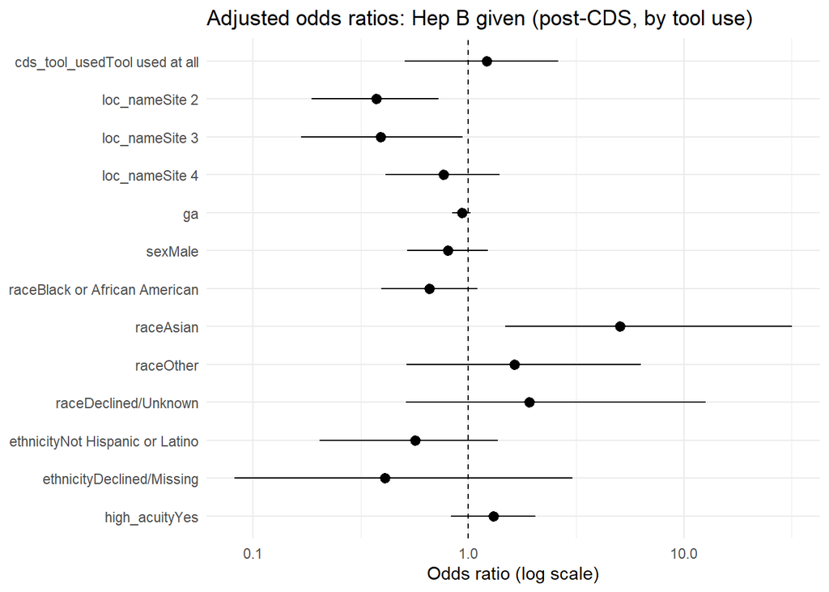

```r
#FP

forest_hepb_any_tool <- tidy_hepb_any_tool_use %>%
  filter(term != "(Intercept)") %>%
  mutate(term = factor(term, levels = rev(term)))

ggplot(forest_hepb_any_tool,
       aes(x = term, y = estimate, ymin = conf.low, ymax = conf.high)) +
  geom_pointrange() +
  geom_hline(yintercept = 1, linetype = "dashed") +
  coord_flip() +
  scale_y_log10() +
  labs(x = NULL,
       y = "Odds ratio (log scale)",
       title = "Adjusted odds ratios: Hep B given (post-CDS, by tool use)") +
  theme_minimal()
```

```r
#logistic regression, outcome: hep b within 7 days, predictor: pre/post cds
model_hepb_7_prepost <- glm(
  hep_b_within_7_days ~ post_cds_flag + loc_name + ga + sex + race +
    ethnicity + high_acuity,
  data   = hepb_model,
  family = binomial
)

tidy_hepb_7_prepost <- tidy(
  model_hepb_7_prepost,
  exponentiate = TRUE,
  conf.int     = TRUE
)

tidy_hepb_7_prepost
```

```
# A tibble: 14 × 7
   term                 estimate std.error statistic  p.value conf.low conf.high
   <chr>                   <dbl>     <dbl>     <dbl>    <dbl>    <dbl>     <dbl>
 1 (Intercept)           0.00329    0.524    -10.9   9.19e-28  0.00118   0.00915
 2 post_cds_flag         0.711      0.0989    -3.45  5.61e- 4  0.587     0.865
 3 loc_nameSite 2        1.70       0.101      5.23  1.73e- 7  1.39      2.08
 4 loc_nameSite 3        0.666      0.0989    -4.11  3.90e- 5  0.549     0.808
 5 loc_nameSite 4        2.87       0.0827    12.8   3.07e-37  2.44      3.38
 6 ga                    1.23       0.0137    15.4   2.98e-53  1.20      1.27
 7 sexMale               0.959      0.0643    -0.658 5.10e- 1  0.845     1.09
 8 raceBlack or Africa…  0.840      0.0783    -2.23  2.61e- 2  0.721     0.980
 9 raceAsian             1.21       0.127      1.47  1.41e- 1  0.944     1.55
10 raceOther             1.08       0.140      0.577 5.64e- 1  0.826     1.43
11 raceDeclined/Unknown  0.793      0.210     -1.11  2.68e- 1  0.531     1.21
12 ethnicityNot Hispan…  0.772      0.138     -1.88  6.00e- 2  0.588     1.01
13 ethnicityDeclined/M…  0.741      0.275     -1.09  2.76e- 1  0.439     1.29
14 high_acuityYes        0.575      0.0723    -7.64  2.13e-14  0.499     0.662
```

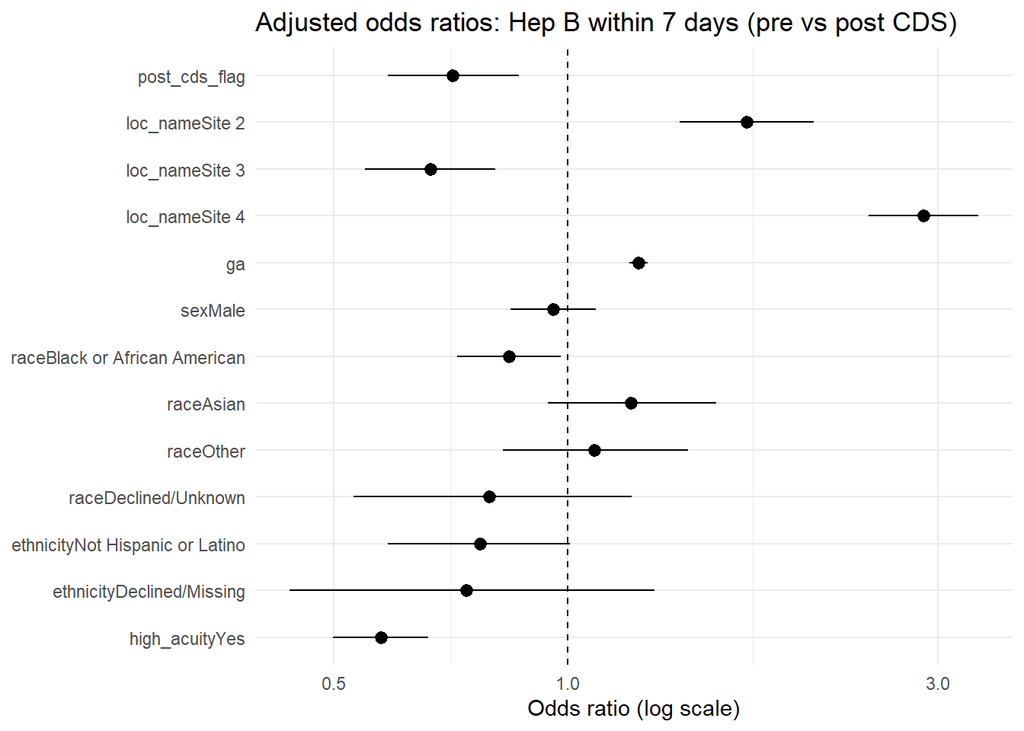

```r
#FP
forest_hepb_7_prepost <- tidy_hepb_7_prepost %>%
  filter(term != "(Intercept)") %>%
  mutate(term = factor(term, levels = rev(term)))

ggplot(forest_hepb_7_prepost,
       aes(x = term, y = estimate, ymin = conf.low, ymax = conf.high)) +
  geom_pointrange() +
  geom_hline(yintercept = 1, linetype = "dashed") +
  coord_flip() +
  scale_y_log10() +
  labs(
    x = NULL,
    y = "Odds ratio (log scale)",
    title = "Adjusted odds ratios: Hep B within 7 days (pre vs post CDS)"
  ) +
  theme_minimal()
```

```r
#logistic regression. outcome: hep b within 7 days, predictor: tool use (only post cds)
model_hepb_7_tool_use <- glm(
  hep_b_within_7_days ~ cds_tool_used + loc_name + ga + sex + race +
    ethnicity + high_acuity,
  data   = hepb_model_post,
  family = binomial
)

tidy_hepb_7_tool_use <- tidy(
  model_hepb_7_tool_use,
  exponentiate = TRUE,
  conf.int     = TRUE
)

tidy_hepb_7_tool_use
```

```
# A tibble: 14 × 7
   term                  estimate std.error statistic p.value conf.low conf.high
   <chr>                    <dbl>     <dbl>     <dbl>   <dbl>    <dbl>     <dbl>
 1 (Intercept)             0.0976    1.63    -1.43    1.53e-1  0.00399     2.40
 2 cds_tool_usedTool us…   0.901     0.407   -0.255   7.98e-1  0.378       1.91
 3 loc_nameSite 2          0.490     0.286   -2.50    1.25e-2  0.278       0.854
 4 loc_nameSite 3          0.268     0.340   -3.88    1.07e-4  0.137       0.521
 5 loc_nameSite 4          0.999     0.252   -0.00370 9.97e-1  0.607       1.63
 6 ga                      1.13      0.0406   3.08    2.05e-3  1.05        1.23
 7 sexMale                 0.822     0.186   -1.05    2.92e-1  0.569       1.18
 8 raceBlack or African…   0.702     0.228   -1.55    1.21e-1  0.448       1.10
 9 raceAsian               1.80      0.399    1.47    1.43e-1  0.858       4.16
10 raceOther               2.40      0.519    1.68    9.21e-2  0.914       7.20
11 raceDeclined/Unknown    2.33      0.646    1.31    1.91e-1  0.752      10.3
12 ethnicityNot Hispani…   0.812     0.366   -0.569   5.69e-1  0.384       1.62
13 ethnicityDeclined/Mi…   1.03      0.825    0.0401  9.68e-1  0.241       7.18
14 high_acuityYes          0.793     0.206   -1.12    2.61e-1  0.525       1.18
```

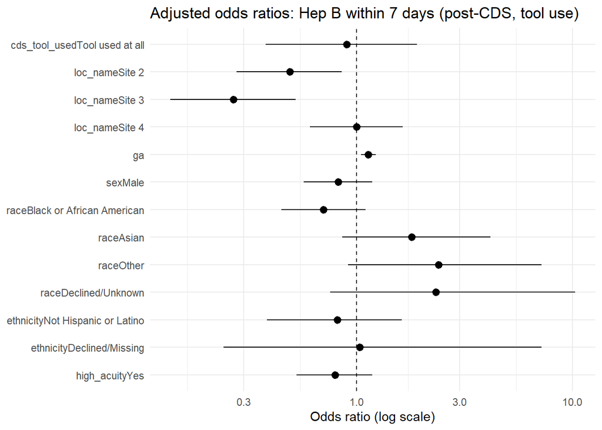

```r
#FP
forest_hepb_7_tool <- tidy_hepb_7_tool_use %>%
  filter(term != "(Intercept)") %>%
  mutate(term = factor(term, levels = rev(term)))

ggplot(forest_hepb_7_tool,
       aes(x = term, y = estimate, ymin = conf.low, ymax = conf.high)) +
  geom_pointrange() +
  geom_hline(yintercept = 1, linetype = "dashed") +
  coord_flip() +
  scale_y_log10() +
  labs(
    x = NULL,
    y = "Odds ratio (log scale)",
    title = "Adjusted odds ratios: Hep B within 7 days (post-CDS, tool use)"
  ) +
  theme_minimal()
```

## 5 Conclusion

> In addition to the declining vaccine rates, there were some other associations that were important to note and bear further discussion. Perhaps most important were the differences by race, with individuals who had Black/African American identities having a reduced odds of hepatitis b vaccination.

> Overall, there was no clear impact of the CDS tool in light of declining hepatitis b vaccination rates. Moving forward, further analyses using quasi-experimental methodologies such as interrupted time series to model the direct impact of the tool may be worth considering.

## 6 References

1. Mercado O, Ruan A, Oluwalade B, Devine M, Gibbs K, Carr L. Leveraging Novel Clinical Decision Support to Improve Preferred Language Documentation in a Neonatal Intensive Care Unit. *Appl Clin Inform*. 2024;15(03):629-636. doi:10.1055/a-2332-5843
2. DuBose JJ, Inaba K, Shiflett A, et al. Measurable Outcomes of Quality Improvement in the Trauma Intensive Care Unit: The Impact of a Daily Quality Rounding Checklist. *Journal of Trauma: Injury, Infection & Critical Care*. 2008;64(1):22-29. doi:10.1097/TA.0b013e318161b0c8
3. Pageler NM, Longhurst CA, Wood M, et al. Use of Electronic Medical Record–Enhanced Checklist and Electronic Dashboard to Decrease CLABSIs. *Pediatrics*. 2014;133(3):e738-e746. doi:10.1542/peds.2013-2249
4. Gawande A. *The Checklist Manifesto: How to Get Things Right*. First Metropolitan Paperbacks Edition. Metropolitan Books; 2022.
5. Carr LH, Padula M, Chuo J, et al. Improving Compliance with a Rounding Checklist through Low- and High-technology Interventions: A Quality Improvement Initiative. *Pediatric Quality & Safety*. 2021;6(4):e437. doi:10.1097/pq9.0000000000000437